# Mercurio

Nicolas Cardenas

2022-09-05

# Overview

La contaminación por mercurio de peces en el agua dulce comestibles es una amenaza directa contra nuestra salud. Se llevó a cabo un estudio reciente en 53 lagos de Florida con el fin de examinar los factores que influían en el nivel de contaminación por mercurio. Las variables que se midieron se encuentran en mercurio.csv Descargar mercurio.csv y su descripción es la siguiente:

X1 = número de indentificación X2 = nombre del lago X3 = alcalinidad (mg/l de carbonato de calcio) X4 = PH X5 = calcio (mg/l) X6 = clorofila (mg/l) X7 = concentración media de mercurio (parte por millón) en el tejido muscualar del grupo de peces estudiados en cada lago X8 = número de peces estudiados en el lago X9 = mínimo de la concentración de mercurio en cada grupo de peces X10 = máximo de la concentración de mercurio en cada grupo de peces X11 = estimación (mediante regresión) de la concentración de mercurio en el pez de 3 años (o promedio de mercurio cuando la edad no está disponible) X12 = indicador de la edad de los peces (0: jóvenes; 1: maduros)

```r
M <- read.csv('mercurio.csv')
colnames(M) <- c("id", "nombre", "alcalinidad", "ph","calcio","clorofila","mediaMercurio","numPeces","minMercurio","maxMercurio","estimacion","madurez")

id = M$id
nombre = M$nombre
alcalinidad = M$alcalinidad
ph = M$ph
calcio = M$calcio
clorofila = M$clorofila
mediaMercurio = M$mediaMercurio
numPeces = M$numPeces
minMercurio = M$minMercurio
maxMercurio = M$maxMercurio
estimacion = M$estimacion
madurez = M$madurez

#Sin ID y si Nombre
Ma <- M[,c(-1,-2)]
```

```r
print("Informacion General de los datos")
```

```
## [1] "Informacion General de los datos"
```

```r
summary(Ma)
```

```
##   alcalinidad           ph            calcio       clorofila
##  Min.   :  1.20   Min.   :3.600   Min.   : 1.1   Min.   :  0.70
##  1st Qu.:  6.60   1st Qu.:5.800   1st Qu.: 3.3   1st Qu.:  4.60
##  Median : 19.60   Median :6.800   Median :12.6   Median : 12.80
##  Mean   : 37.53   Mean   :6.591   Mean   :22.2   Mean   : 23.12
##  3rd Qu.: 66.50   3rd Qu.:7.400   3rd Qu.:35.6   3rd Qu.: 24.70
##  Max.   :128.00   Max.   :9.100   Max.   :90.7   Max.   :152.40
##  mediaMercurio       numPeces      minMercurio      maxMercurio
##  Min.   :0.0400   Min.   : 4.00   Min.   :0.0400   Min.   :0.0600
##  1st Qu.:0.2700   1st Qu.:10.00   1st Qu.:0.0900   1st Qu.:0.4800
##  Median :0.4800   Median :12.00   Median :0.2500   Median :0.8400
##  Mean   :0.5272   Mean   :13.06   Mean   :0.2798   Mean   :0.8745
##  3rd Qu.:0.7700   3rd Qu.:12.00   3rd Qu.:0.3300   3rd Qu.:1.3300
##  Max.   :1.3300   Max.   :44.00   Max.   :0.9200   Max.   :2.0400
##    estimacion        madurez
##  Min.   :0.0400   Min.   :0.0000
##  1st Qu.:0.2500   1st Qu.:1.0000
##  Median :0.4500   Median :1.0000
##  Mean   :0.5132   Mean   :0.8113
##  3rd Qu.:0.7000   3rd Qu.:1.0000
##  Max.   :1.5300   Max.   :1.0000
```

```r
print("Desviacion Estandar")
```

```
## [1] "Desviacion Estandar"
```

```r
apply(Ma,2,sd)
```

```
##   alcalinidad            ph        calcio     clorofila mediaMercurio
##    38.2035267     1.2884493    24.9325744    30.8163214     0.3410356
##      numPeces   minMercurio   maxMercurio    estimacion       madurez
##     8.5606773     0.2264058     0.5220469     0.3387294     0.3949977
```

## LIMPIEZA

A primer vistazo, no vemos ninguna indiscrepancia en los datos, todos los minimos y maximos se observan en orden, no hay datos duplicados, no hay N/A, la alcalinidad esta dentro de los rangos validos de la escala pH, asi que podemos proceder con un analisis general de los datos para empezar.

Lo unico que vamos a hacer es cambiar el dummy de joven y maduro (0 y 1) a una variable categorica para poder correr el anova test en el futuro.

```r
M$edad <- Map(function(element) {ifelse(element == 1, 'joven','maduro')},M$madurez)
edad = unlist(do.call(rbind.data.frame, M$edad))
```

Conteo de valores nulos por columna, vemos que todos son 0 por lo cual no contamos con indiscrepancias.

```r
na_count <-sapply(Ma, function(y) sum(length(which(is.na(y)))))
na_count
```

```
##   alcalinidad            ph        calcio     clorofila mediaMercurio
##             0             0             0             0             0
##      numPeces   minMercurio   maxMercurio    estimacion       madurez
##             0             0             0             0             0
```

En cuanto a limpieza de datos atipicos/extremos los veremos en el analisis.

## ANALISIS

Para nuestra variable objetivo durante este analisis debemos primero determinar lo que nos pide el problema: medir los factores de de mercurio. Dentro de nuestra tabla tenemos varias variables para medir el nivel de mercurio: media, minimo, maximo, y la de estimacion. Primero que nada descartare la de estimacion ya que esa fue hecha con regresion lineal cuando no estaba la informacion en cuanto a la edad asi que esa ya contiene un grado de error, ademas utilizaron la media por lo tanto muestra alta correlacion con la media. Y es por esto que creo que debemos enfocarnos en la media de mercurio en los peces ya que esta nos da una cifra pero tambien nos puede dar un intervalo de confianza donde podemos poner la media de la poblacion. Al principio estaba debatiendo si analizar el maximo del mercurio ya que este es el que importa, no queremos que ningun pez sobresalga de el maximo permitido para la salud. Sin embargo, como vemos que hay una correlacion alta entre la media y el maximo en este caso, creo que la media nos brindaria mas informacion y podemos hacer inferencias del maximo, asimismo, no queremos que datos atipicos nos alteren el maximo y tengamos una percepcion alterada.

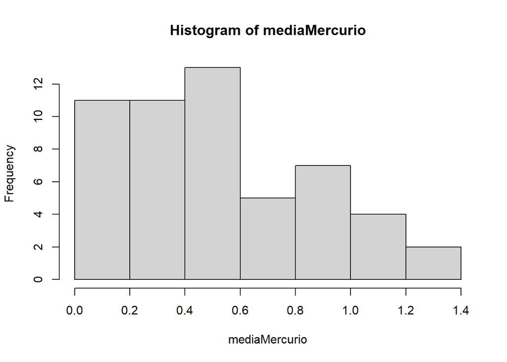

```r
hist(mediaMercurio)
```

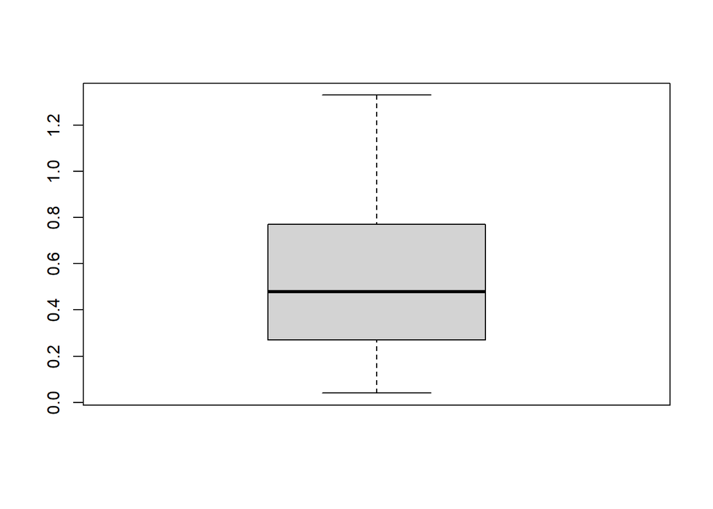

```r
boxplot(mediaMercurio)
```

```r
#Sin la media de mercurio y sin variables categoricas
sinPredict <- Ma[-5,-10]
```

# Medias

Ya que nuestra variable objetivo es la media del nivel del mercurio encontrado de los peces de ese lago, quisiera ver que tanto se relacion al numero de peces medidos. Lo primero que haremos es ver la grafica entre numPeces y la media de mercurio.

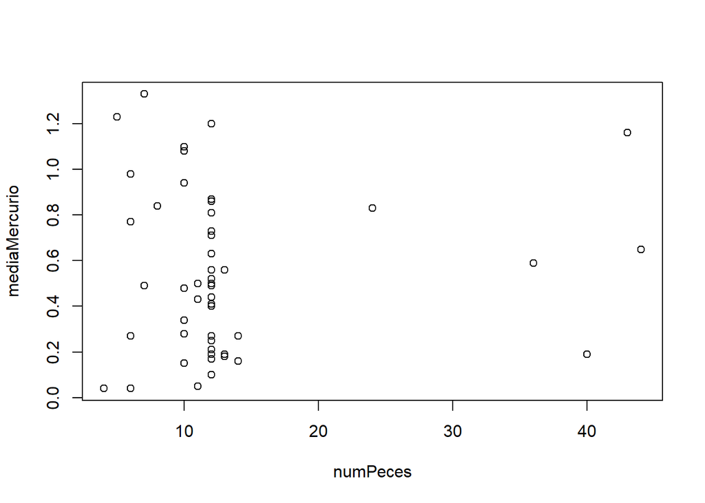

```r
plot(numPeces,mediaMercurio)
```

No vemos un ningun tipo de correlacion entre estas o algun patron que podamos analizar lo cual es bueno, significa que no porque haya mas peces y la media sea mas precisa o cambie drasticamente.

# Toxicidiad

Antes de proceder a analizar cuales seran los factores principales en cuanto a toxicidad de mercurio en el agua, hay que observar la media en cuanto todos los lagos para ver si realmente es un problema que hay en Florida. Para esto utilizaremos los reglamentos internacionales CE 1881/2006 y Codex Standard 193-1995 que indican que la concentración promedio de mercurio en productos de la pesca no debe superar los 0.5 mg de Hg/kg.

H0 = La media de la media de mercurio en los peces en lagos de Florida es < 0.5 H1 = La media de la media de mercurio en los peces en lagos de Florida es > 0.5

Para esta prueba de hipotesis utilizaremos un alpha de 0.05

Para la distribucion opte por utilizar la t de student debido a que tenemos mas de 30 datos y no conocemos sigma.

Primero debemos encontrar t0.

```r
alfa = 0.05
n = length(mediaMercurio)
t0 = qt(alfa, n - 2)
t0
```

```
## [1] -1.675285
```

Esta prueba es solo cola hacia la derecha ya que solo se rechaza si es mayor.

Por lo tanto rechazaremos si: * Valor p es menor a 0.05 * Si |t estrella| > | t0

```r
m = mean(mediaMercurio)
s = sd(mediaMercurio)
n = length(mediaMercurio)

sig = s / sqrt(n)

miuHipotesis = 0.5
testrella = (m - miuHipotesis) / sig
testrella
```

```
## [1] 0.5799957
```

```r
pvalue=2*pt(testrella,n-2)
pvalue
```

```
## [1] 1.435529
```

```r
abs(testrella) > abs(t0)
```

```
## [1] FALSE
```

```r
pvalue < 0.05
```

```
## [1] FALSE
```

Otra cosa que podriamos analizar que tambien considero que podria ser extremadamente util seria sacar el intervalo de la media para cada lago, para saber especificamente por lago que tan toxico es y no solo en promedio de Florida.

# Correlacion

```r
#Matriz correlacion + pvalues
library("Hmisc")
res <- rcorr(as.matrix(Ma))
res
```

```
##               alcalinidad    ph calcio clorofila mediaMercurio numPeces
## alcalinidad          1.00  0.72   0.83      0.48         -0.59     0.01
## ph                   0.72  1.00   0.58      0.61         -0.58    -0.02
## calcio               0.83  0.58   1.00      0.41         -0.40    -0.09
## clorofila            0.48  0.61   0.41      1.00         -0.49    -0.01
## mediaMercurio       -0.59 -0.58  -0.40     -0.49          1.00     0.08
## numPeces             0.01 -0.02  -0.09     -0.01          0.08     1.00
## minMercurio         -0.53 -0.54  -0.33     -0.40          0.93    -0.08
## maxMercurio         -0.60 -0.55  -0.41     -0.48          0.92     0.16
## estimacion          -0.63 -0.61  -0.46     -0.51          0.96     0.03
## madurez             -0.09  0.04   0.00     -0.28          0.11     0.21
##               minMercurio maxMercurio estimacion madurez
## alcalinidad         -0.53       -0.60      -0.63   -0.09
## ph                  -0.54       -0.55      -0.61    0.04
## calcio              -0.33       -0.41      -0.46    0.00
## clorofila           -0.40       -0.48      -0.51   -0.28
## mediaMercurio        0.93        0.92       0.96    0.11
## numPeces            -0.08        0.16       0.03    0.21
## minMercurio          1.00        0.77       0.92    0.10
## maxMercurio          0.77        1.00       0.86    0.09
## estimacion           0.92        0.86       1.00    0.09
## madurez              0.10        0.09       0.09    1.00
##
## n= 53
##
##
## P
##               alcalinidad ph     calcio clorofila mediaMercurio numPeces
## alcalinidad               0.0000 0.0000 0.0003    0.0000        0.9417
## ph            0.0000             0.0000 0.0000    0.0000        0.8948
## calcio        0.0000      0.0000        0.0023    0.0029        0.5245
## clorofila     0.0003      0.0000 0.0023           0.0002        0.9331
## mediaMercurio 0.0000      0.0000 0.0029 0.0002                  0.5737
## numPeces      0.9417      0.8948 0.5245 0.9331    0.5737
## minMercurio   0.0000      0.0000 0.0150 0.0030    0.0000        0.5611
## maxMercurio   0.0000      0.0000 0.0024 0.0002    0.0000        0.2492
## estimacion    0.0000      0.0000 0.0005 0.0001    0.0000        0.8545
## madurez       0.4989      0.7870 0.9880 0.0400    0.4383        0.1351
##               minMercurio maxMercurio estimacion madurez
## alcalinidad   0.0000      0.0000      0.0000     0.4989
## ph            0.0000      0.0000      0.0000     0.7870
## calcio        0.0150      0.0024      0.0005     0.9880
## clorofila     0.0030      0.0002      0.0001     0.0400
## mediaMercurio 0.0000      0.0000      0.0000     0.4383
## numPeces      0.5611      0.2492      0.8545     0.1351
## minMercurio               0.0000      0.0000     0.4733
## maxMercurio   0.0000                  0.0000     0.5043
## estimacion    0.0000      0.0000                 0.5243
## madurez       0.4733      0.5043      0.5243
```

```r
#Con estas funciones nos damos una idea visual para poder ver cuales son las variables que mas tienen correlacion.
symnum(res$r)
```

```
##               a p clc clr mdM n mnM mxM e md
## alcalinidad   1
## ph            , 1
## calcio        + . 1
## clorofila     . , .   1
## mediaMercurio . . .   .   1
## numPeces                      1
## minMercurio   . . .   .   *     1
## maxMercurio   , . .   .   *     ,   1
## estimacion    , , .   .   B     *   +   1
## madurez                                   1
## attr(,"legend")
## [1] 0 ' ' 0.3 '.' 0.6 ',' 0.8 '+' 0.9 '*' 0.95 'B' 1
```

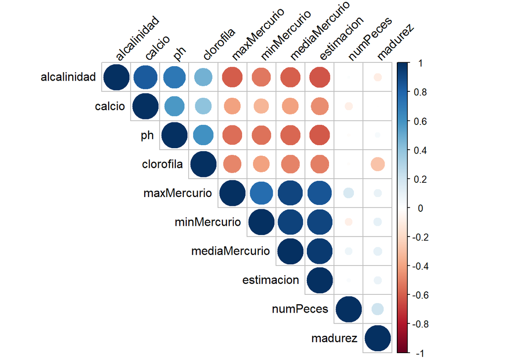

```r
library(corrplot)
corrplot(res$r, type = "upper", order = "hclust", tl.col = "black", tl.srt = 45)
```

```r
library(PerformanceAnalytics)
```

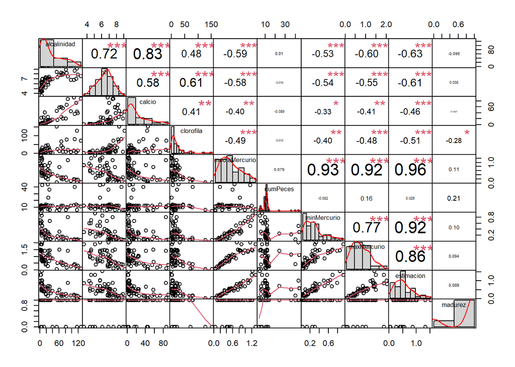

```r
chart.Correlation(Ma, histogram=TRUE, pch=19)
```

# Anova

Primero que nada haremos una prueba de anova con la madurez de los peces, y como ya lo mencionamos antes usaremos el promedio de mercurio en los peces como variable dependiente. Haremos esto primero ya que es nuestra unica variable categorica.

H0: No hay efecto debido a la edad en la media de los mercurio en los peces H1: Si hay efecto debido a la edad en la media de los mercurio en los peces

Criterio de Rechazo P(F*>F0) < 0.05

Primero veremos un boxplot representando la edad de los peces (joven,adulto)

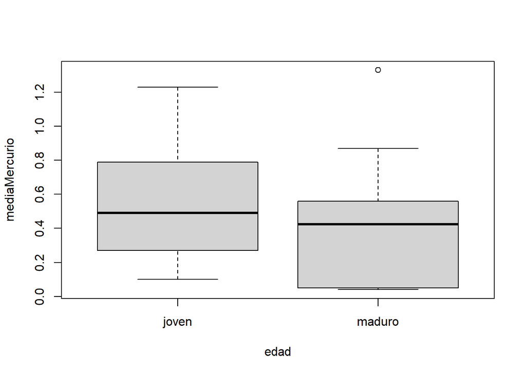

```r
boxplot(mediaMercurio~edad)
```

Como podemos ver la media es similar en ambos, sin embargo se ven diferentes los diagramas en terminos de rangos intercuartiles, asi que procederemos con el ANOVA test.

```r
A<-aov(mediaMercurio~edad)
summary(A)
```

```
##             Df Sum Sq Mean Sq F value Pr(>F)
## edad         1  0.072 0.07151    0.61  0.438
## Residuals   51  5.976 0.11718
```

Como podemos ver, vemos que no hay efecto. Pr>F es demasiado alta por lo tanto no rechazamos la hipotesis nula y concluimos que NO hay efecto. La edad es la unica variable categorica que podemos analizar con ANOVA. Por lo tanto utilizaremos otros metodos para analizar las otras variables.

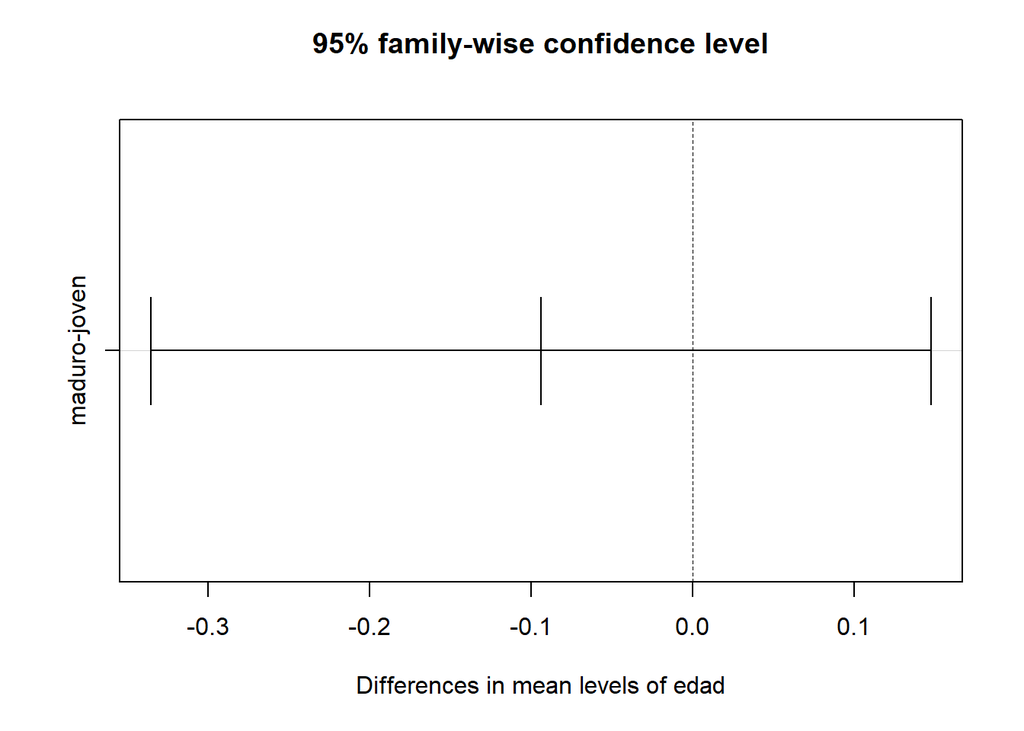

```r
I = TukeyHSD(aov(mediaMercurio ~ edad))
plot(I)
```

El intervalo pasa por cero, lo cual me indica que son iguales y como lo mencionamos anteriormente no hay efecto.

# Regresion Lineal

Utilizando nuestra matriz anterior, haremos una regresion lineal para ver cuales variables tienen mayor efecto en nuestra variabla dependiente (media del mercurio)

Antes de empezar a realizar los modelos me gustaria tener una funcion para tambien analizar los residuos:

```r
#Funcion para analisis
analyzeResiduals <- function(A) {
  shapiro.test(A$residuals)
  qqnorm(A$residuals)
  qqline(A$residuals)
  hist(A$residuals,freq=FALSE)
  lines(density(A$residual),col="red")
  curve(dnorm(x,mean=mean(A$residuals),sd=sd(A$residuals)), from=-6, to=6, add=TRUE, col="blue",lwd=2)
}
```

```r
lr = lm(mediaMercurio~ph+alcalinidad+clorofila+calcio)
summary(lr)
```

```
##
## Call:
## lm(formula = mediaMercurio ~ ph + alcalinidad + clorofila + calcio)
##
## Residuals:
##      Min       1Q   Median       3Q      Max
## -0.42260 -0.19155 -0.08438  0.14334  0.62234
##
## Coefficients:
##              Estimate Std. Error t value Pr(>|t|)
## (Intercept)  1.004440   0.257561   3.900 0.000299 ***
## ph          -0.046709   0.045329  -1.030 0.307968
## alcalinidad -0.005503   0.002028  -2.713 0.009224 **
## clorofila   -0.002361   0.001497  -1.577 0.121257
## calcio       0.004129   0.002648   1.559 0.125484
## ---
## Signif. codes:  0 '***' 0.001 '**' 0.01 '*' 0.05 '.' 0.1 ' ' 1
##
## Residual standard error: 0.2629 on 48 degrees of freedom
## Multiple R-squared:  0.4515, Adjusted R-squared:  0.4058
## F-statistic: 9.879 on 4 and 48 DF,  p-value: 6.499e-06
```

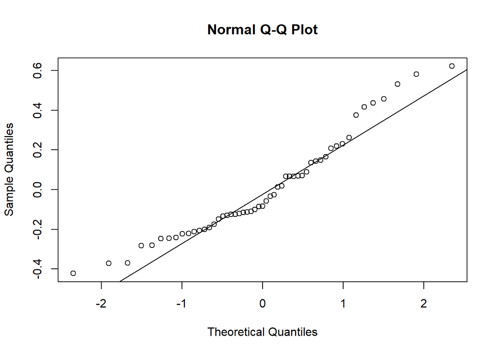

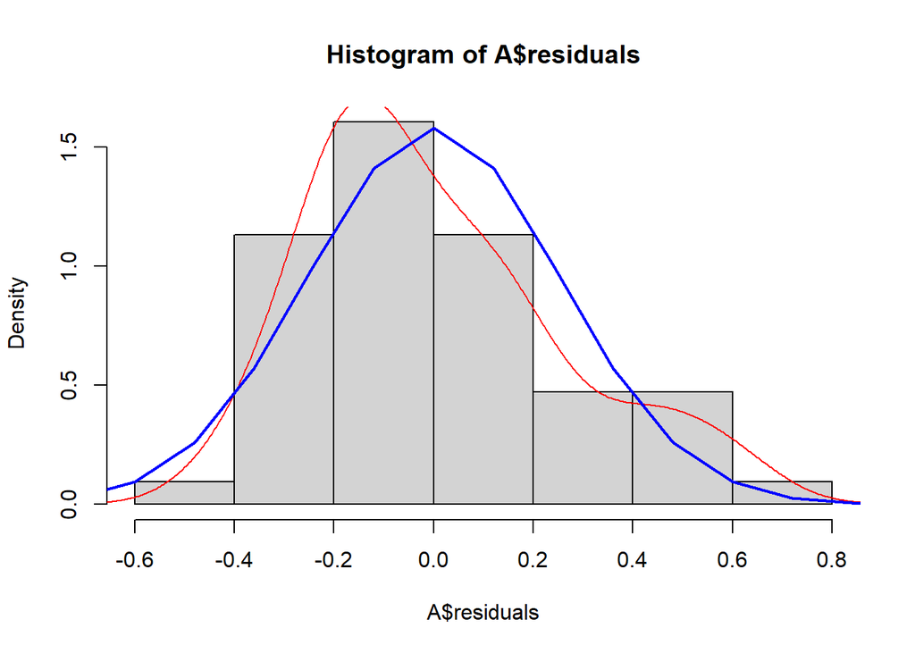

```r
analyzeResiduals(lr)
```

Como podemos ver, los unicos que si tienen efecto en la media es la alcalinidad, sin embargo tenemos 2 variables que tambien tienen un valor p bajo, no abajo de nuestra alfa, pero considero que son importantes mantener. Por ahora quitaremos solo el que tuvo el valor p mas alto que fue el ph y cambiaremos el modelo para ver como interactua ahora. En cuanto a los residuos podemos ver que no se distribuyen normalmente, lo cual indica un mal modelo. Trataremos ahora de modelar con solo las variables que fueron lo suficientemente significativas:

```r
lr = lm(mediaMercurio~clorofila+alcalinidad+calcio)
summary(lr)
```

```
##
## Call:
## lm(formula = mediaMercurio ~ clorofila + alcalinidad + calcio)
##
## Residuals:
##      Min       1Q   Median       3Q      Max
## -0.38746 -0.18520 -0.07092  0.14490  0.61422
##
## Coefficients:
##              Estimate Std. Error t value Pr(>|t|)
## (Intercept)  0.744583   0.052401  14.209  < 2e-16 ***
## clorofila   -0.003035   0.001348  -2.252 0.028862 *
## alcalinidad -0.006487   0.001790  -3.624 0.000689 ***
## calcio       0.004333   0.002642   1.640 0.107445
## ---
## Signif. codes:  0 '***' 0.001 '**' 0.01 '*' 0.05 '.' 0.1 ' ' 1
##
## Residual standard error: 0.263 on 49 degrees of freedom
## Multiple R-squared:  0.4394, Adjusted R-squared:  0.4051
## F-statistic:  12.8 on 3 and 49 DF,  p-value: 2.676e-06
```

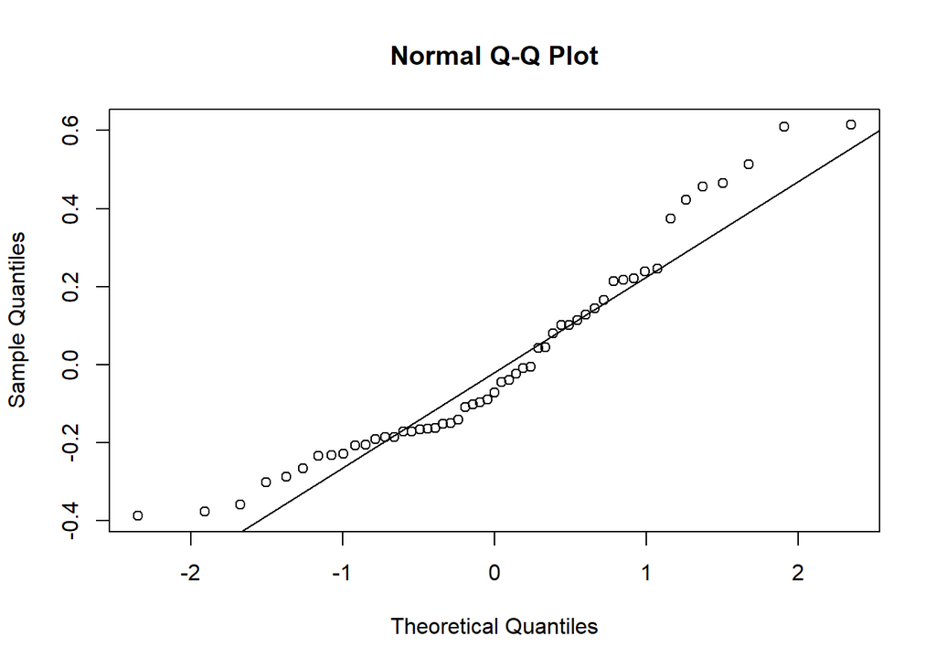

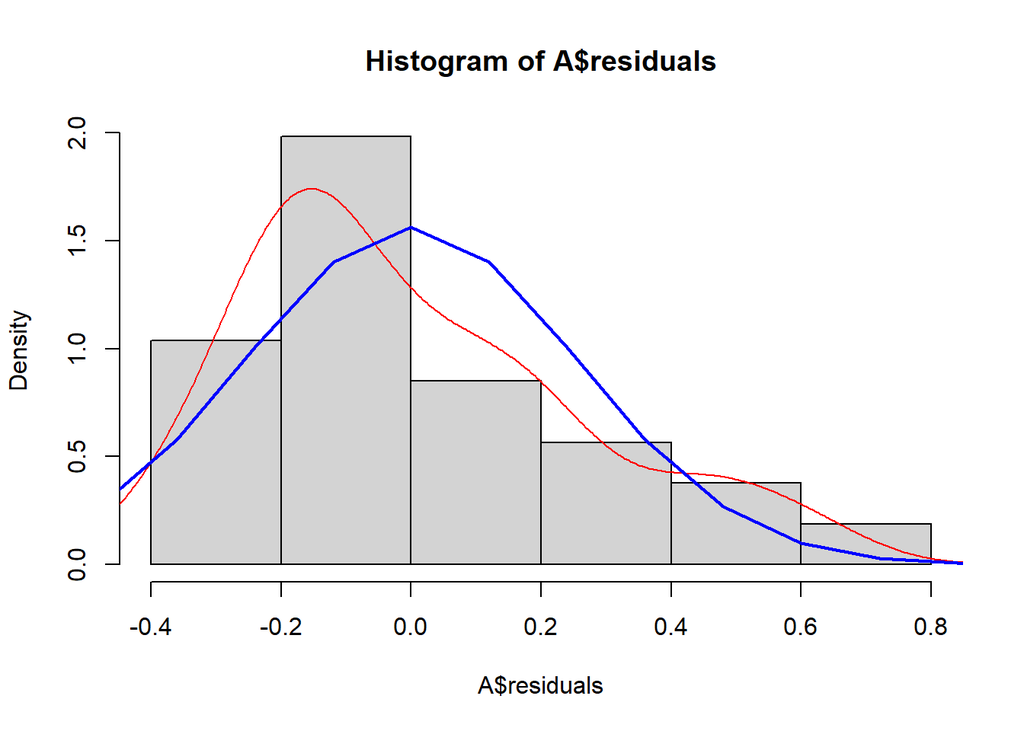

```r
analyzeResiduals(lr)
```

Finalmente modelamos con solo nuestras variables que fueron significantes para obtener un nuevo modelo:

```r
lr = lm(mediaMercurio~clorofila+alcalinidad)
summary(lr)
```

```
##
## Call:
## lm(formula = mediaMercurio ~ clorofila + alcalinidad)
##
## Residuals:
##      Min       1Q   Median       3Q      Max
## -0.42232 -0.18500 -0.06314  0.14502  0.77185
##
## Coefficients:
##              Estimate Std. Error t value Pr(>|t|)
## (Intercept)  0.751936   0.053084  14.165  < 2e-16 ***
## clorofila   -0.002979   0.001370  -2.174 0.034433 *
## alcalinidad -0.004154   0.001105  -3.760 0.000446 ***
## ---
## Signif. codes:  0 '***' 0.001 '**' 0.01 '*' 0.05 '.' 0.1 ' ' 1
##
## Residual standard error: 0.2675 on 50 degrees of freedom
## Multiple R-squared:  0.4086, Adjusted R-squared:  0.385
## F-statistic: 17.27 on 2 and 50 DF,  p-value: 1.979e-06
```

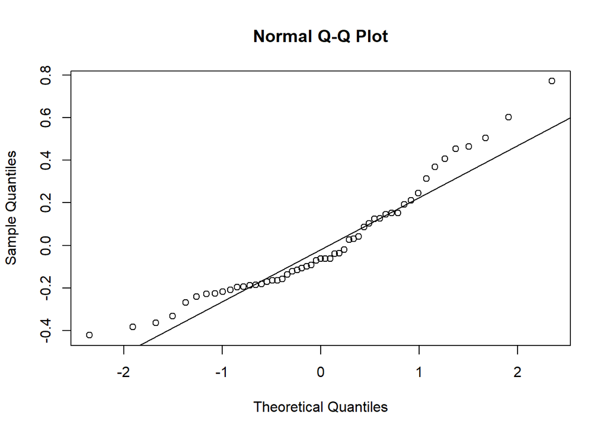

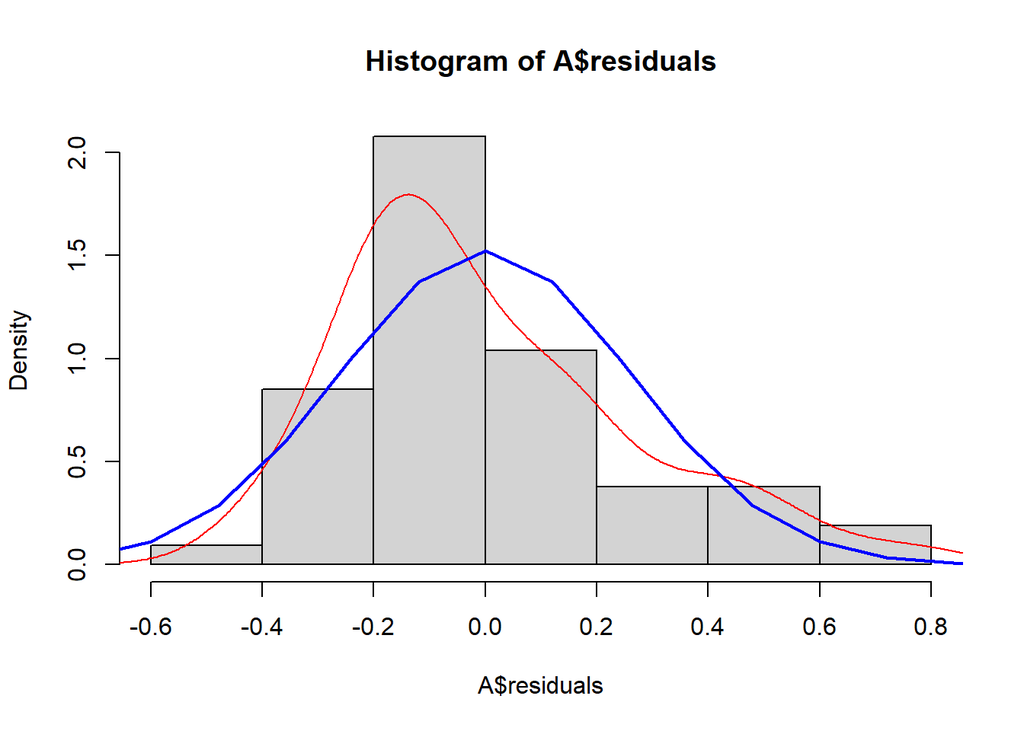

```r
analyzeResiduals(lr)
```

Como podemos ver el valor p para clorofila y alcalinidad son menores que nuestra alfa, indicando que si hay efecto, sin embargo, este modelo no lo esta modelando apropiadamente ya que tenemos una R^2 mas baja ahora.

Antes de proceder, valdria la pena evaluar el modelo con clorofila y alcalinidad interactuando, para observar si es un mejor modelo:

```r
lr = lm(mediaMercurio~clorofila*alcalinidad)
summary(lr)
```

```
##
## Call:
## lm(formula = mediaMercurio ~ clorofila * alcalinidad)
##
## Residuals:
##      Min       1Q   Median       3Q      Max
## -0.44742 -0.19201 -0.04896  0.12296  0.79908
##
## Coefficients:
##                         Estimate Std. Error t value Pr(>|t|)
## (Intercept)            8.020e-01  6.448e-02  12.439  < 2e-16 ***
## clorofila             -6.310e-03  2.823e-03  -2.235 0.030012 *
## alcalinidad           -5.221e-03  1.352e-03  -3.860 0.000332 ***
## clorofila:alcalinidad  4.718e-05  3.505e-05   1.346 0.184453
## ---
## Signif. codes:  0 '***' 0.001 '**' 0.01 '*' 0.05 '.' 0.1 ' ' 1
##
## Residual standard error: 0.2653 on 49 degrees of freedom
## Multiple R-squared:  0.4297, Adjusted R-squared:  0.3948
## F-statistic: 12.31 on 3 and 49 DF,  p-value: 4.029e-06
```

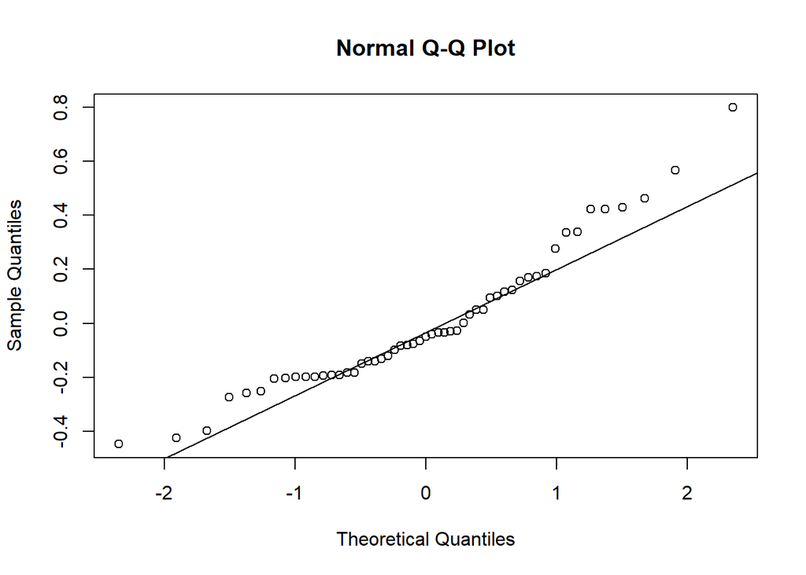

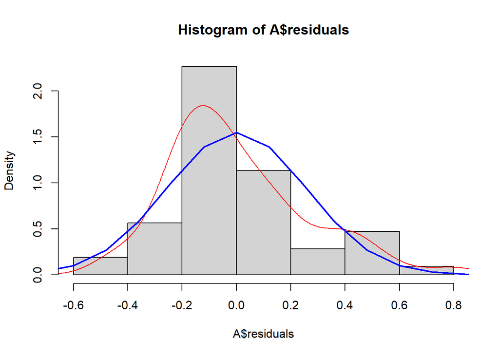

```r
analyzeResiduals(lr)
```

Igualmente es un mal modelo. Los residuos de distribuyen de manera no formal. Todos nuestros en estos tres modelos muestran sesgo a la derecha y una curtosis positiva.

#Modelo Este modelo sigue siendo malo, sin embargo, no hay duda que hay efecto de estas dos variables en la media del mercurio, para esto vamos a analizar como se comporta la media con cada una de estas variables por separado.

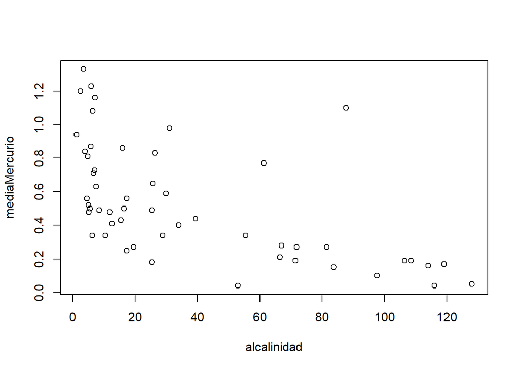

```r
plot(alcalinidad,mediaMercurio)
```

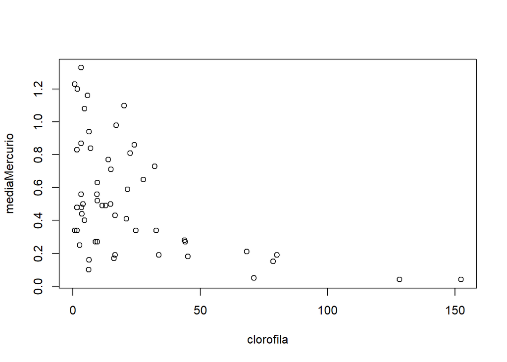

```r
plot(clorofila,mediaMercurio)
```

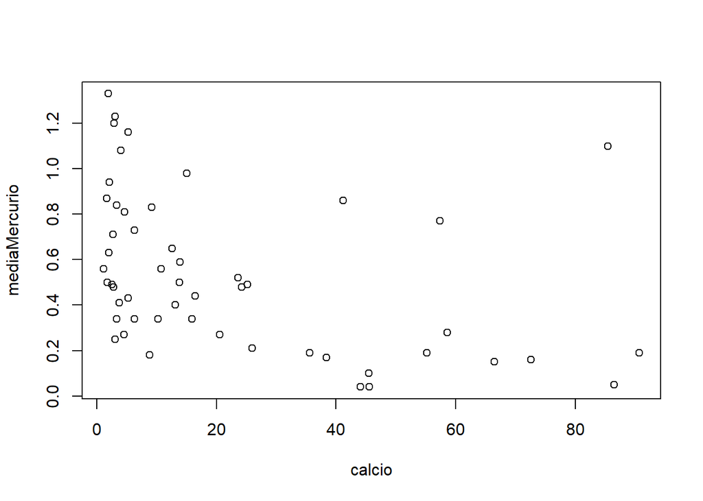

```r
plot(calcio,mediaMercurio)
```

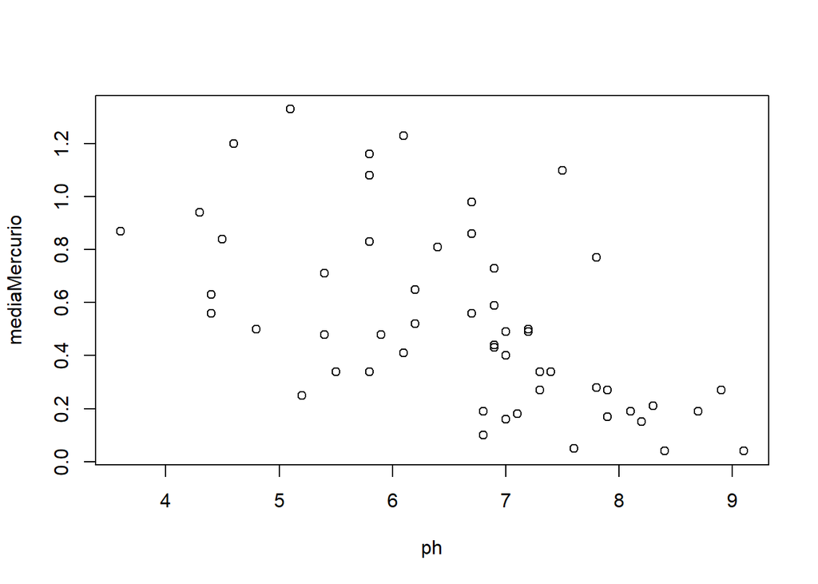

```r
plot(ph,mediaMercurio)
```

Como podemos ver la tendencia de estas dos variables no es linear. Se muestra como una exponencial decreciente con concava positiva (n^x). Esto explica porque el modelo no se ajusta bien a pesar de que si muestran efecto.

Como lo que se busca encontrar en esta investigacion es cuales factores afectan el agua y no predecir los niveles de mercurio, no es necesario encontrar un modelo de mejor ajuste. Contamos ya con las variables que tienen efecto sobre la media de nivel de mercurio en los peces y podemos dar como concluida la investigacion.

Sin embargo, si quisieramos construir un modelo para predecir la media del mercurio, podemos analizar como se comportarian estas variables con un modelo exponencial.

```r
model <- lm(log(mediaMercurio)~ alcalinidad+clorofila)
summary(model)
```

```
##
## Call:
## lm(formula = log(mediaMercurio) ~ alcalinidad + clorofila)
##
## Residuals:
##      Min       1Q   Median       3Q      Max
## -0.96716 -0.27599 -0.08178  0.32685  1.50399
##
## Coefficients:
##              Estimate Std. Error t value Pr(>|t|)
## (Intercept) -0.209275   0.095504  -2.191   0.0331 *
## alcalinidad -0.010729   0.001988  -5.397 1.86e-06 ***
## clorofila   -0.012912   0.002464  -5.239 3.24e-06 ***
## ---
## Signif. codes:  0 '***' 0.001 '**' 0.01 '*' 0.05 '.' 0.1 ' ' 1
##
## Residual standard error: 0.4812 on 50 degrees of freedom
## Multiple R-squared:  0.6841, Adjusted R-squared:  0.6715
## F-statistic: 54.14 on 2 and 50 DF,  p-value: 3.083e-13
```

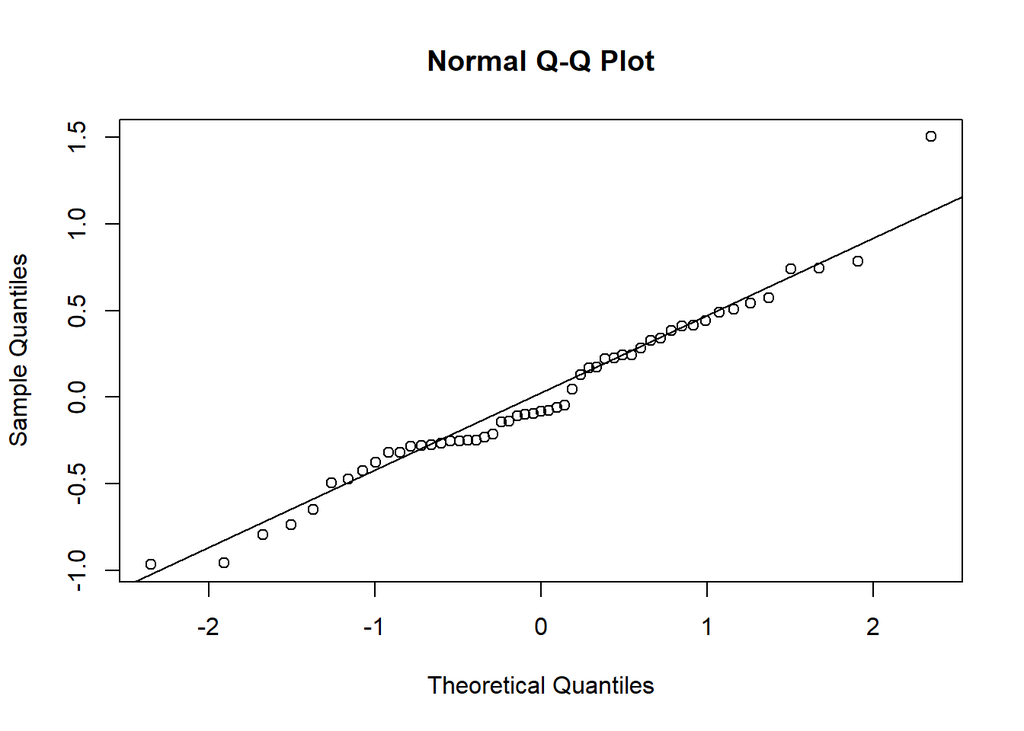

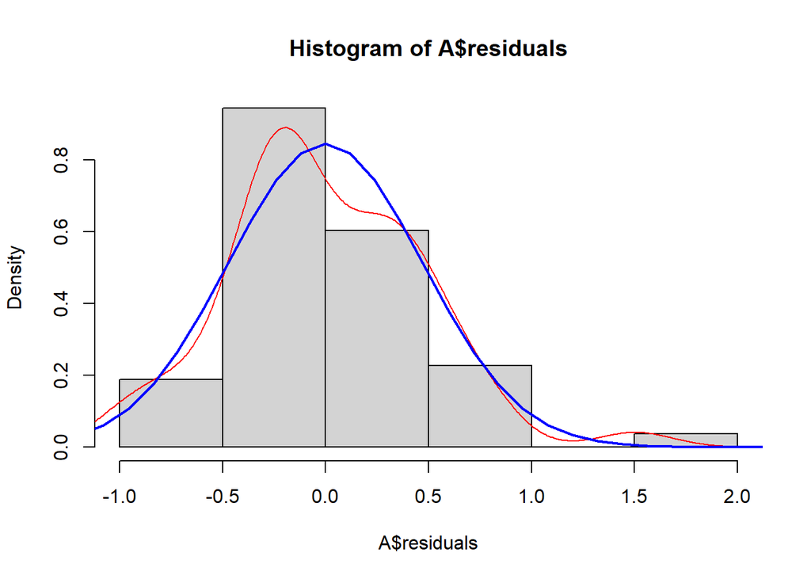

```r
analyzeResiduals(model)
```

No solo tenemos la mejor R^2 hasta ahora si no que tambien nuestros residuos parecen distribuirse de una manera mas normal. No es perfecto pero indica nuevamente que el mejor modelo hasta ahorita.

Si quisieramos mejorar nuestro modelo para predecir, usariamos todas las variables, pero si utilizamos todos, las demas variables no tendrian efecto en la media pero mejoraria nuestra R^2. Solo como referencia haremos el analisis del modelo con todas las variables solo para tener el mejor modelo posible.

```r
model <- lm(log(mediaMercurio)~ alcalinidad+clorofila+ph+madurez+calcio)
summary(model)
```

```
##
## Call:
## lm(formula = log(mediaMercurio) ~ alcalinidad + clorofila + ph +
##     madurez + calcio)
##
## Residuals:
##      Min       1Q   Median       3Q      Max
## -0.89693 -0.31675  0.00029  0.30284  1.22458
##
## Coefficients:
##              Estimate Std. Error t value Pr(>|t|)
## (Intercept) -0.486670   0.470447  -1.034 0.306203
## alcalinidad -0.015170   0.003819  -3.972 0.000243 ***
## clorofila   -0.012911   0.002974  -4.341 7.49e-05 ***
## ph           0.027874   0.087686   0.318 0.751985
## madurez      0.125113   0.188551   0.664 0.510220
## calcio       0.007154   0.004922   1.453 0.152758
## ---
## Signif. codes:  0 '***' 0.001 '**' 0.01 '*' 0.05 '.' 0.1 ' ' 1
##
## Residual standard error: 0.4801 on 47 degrees of freedom
## Multiple R-squared:  0.7043, Adjusted R-squared:  0.6729
## F-statistic: 22.39 on 5 and 47 DF,  p-value: 2.059e-11
```

# CONCLUSION

Lo que podemos asumir es que entre mas baja la alcalinidad y mas baja la clorofila, la media del mercurio suele ser mas alta, sin embargo, si la incrementamos por un poco baja drasticamente y despues a como vamos incrementando estas dos variables, la media del mercurio baja semi-constantemente. Por lo tanto, si quisieramos bajar el mercurio en los peces por la contaminacion debemos encargarnos de incrementar la clorofila y la alcalinidad.

Tras una investigacion corta en internet, encontramos que los niveles de alcalinidad bajos en el agua hace que el ph fluctue altamente en el agua que causa danos a todo lo que hace contacto con ella. Niveles de clorofila bajos indican que hay muy poca vida microscopica en el agua, que creo que tambien es senal de altos niveles de mercurio ya que indica que hay poca vida ahi, probablemente por la contaminacion que ya hay.

En conclusion, las caracteristicas del agua que mas suelen afectar los niveles de mercurio en el agua son la alcalinidad y la clorofila.